# Analyse des données des joueurs (expérimentations finales)

# Cadre des expérimentations pilotes

Les expérimentations pilotes ont pu être menés du 6 au 10 septembre, dans les mêmes conditions que celles prévues pour les expérimentations finales, à savoir dans les locaux du Living Lab auprès du public cible. Sur cette période, 32 personnes ont participé aux expérimentations, mais seulement 8 d’entre-elles ont pu tester la version finalisée du jeu (le prototype ayant évolué au cours de ces expérimentations). Ces huit personnes ont expérimenté les trois jeux de manière aléatoire (pour éviter tout effet d’ordre et de fatigue), réalisant 30 tours de jeu pour chaque tâche dédiée à un type de difficulté (logique, sensorielle et motrice). Au total, nous obtenons 240 observations pour un jeu, soit 720 observations recouvrant l’ensemble des trois types de difficulté.

Pour un joueur identifié, nous nous focalisons sur les données suivantes :

- la **mise**, révélant leur confiance vis-à-vis de leur action de jeu ;
- le **tour de jeu**, spécifiant la position du joueur au cours de la progression (allant de 1, début du jeu, à 30, dernier tour de jeu) ;
- la **difficulté** du jeu à un tour de jeu donné (comprise entre 0 -facile- et 1 -très difficile-) ;
- l’**état de réussite** du joueur en sortie de tour, à savoir s’il est gagnant (1) ou perdant (0).

# Estimation de la difficulté objective

```
##
## Call:
## glm(formula = evalDiffBin ~ difficulty, family = binomial(link = "logit"),
##     data = DTLoc)
##
## Deviance Residuals:
##     Min       1Q   Median       3Q      Max
## -1.1766  -0.9922  -0.9424   1.3177   1.4611
##
## Coefficients:
##             Estimate Std. Error z value Pr(>|z|)
## (Intercept) -0.64596    0.07081  -9.122  < 2e-16 ***
## difficulty   0.64414    0.15190   4.240 2.23e-05 ***
## ---
## Signif. codes:  0 '***' 0.001 '**' 0.01 '*' 0.05 '.' 0.1 ' ' 1
##
## (Dispersion parameter for binomial family taken to be 1)
##
##     Null deviance: 3107.7  on 2309  degrees of freedom
## Residual deviance: 3089.7  on 2308  degrees of freedom
## AIC: 3093.7
##
## Number of Fisher Scoring iterations: 4
```

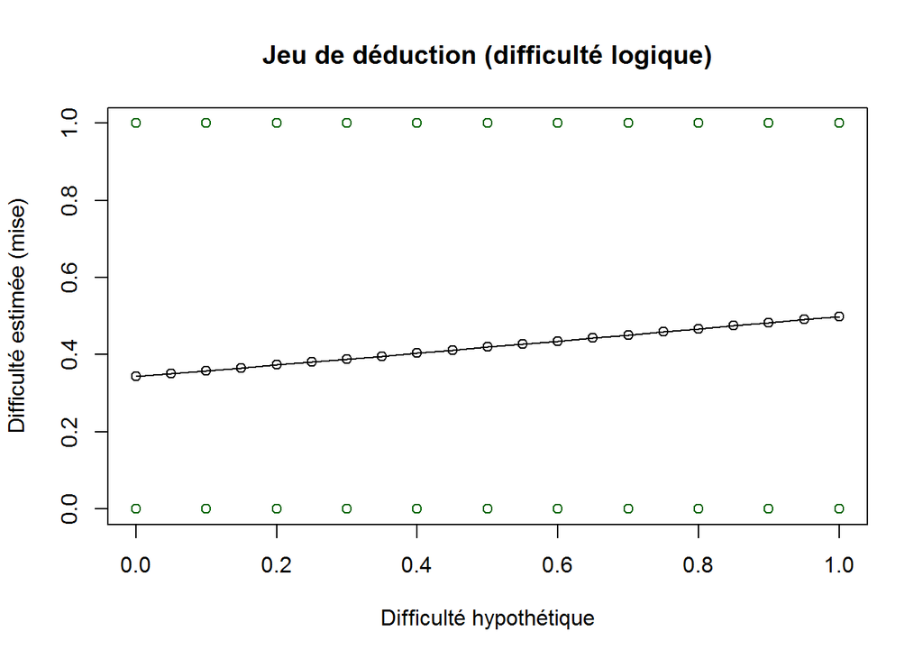

```
##
## Call:
## glm(formula = perdant ~ difficulty, family = binomial(link = "logit"),
##     data = DTLoc)
##
## Deviance Residuals:
##     Min       1Q   Median       3Q      Max
## -1.3914  -1.0094  -0.8636   1.2426   1.5278
##
## Coefficients:
##             Estimate Std. Error z value Pr(>|z|)
## (Intercept) -0.79417    0.07177 -11.066   <2e-16 ***
## difficulty   1.28437    0.15380   8.351   <2e-16 ***
## ---
## Signif. codes:  0 '***' 0.001 '**' 0.01 '*' 0.05 '.' 0.1 ' ' 1
##
## (Dispersion parameter for binomial family taken to be 1)
##
##     Null deviance: 3144.1  on 2309  degrees of freedom
## Residual deviance: 3072.6  on 2308  degrees of freedom
## AIC: 3076.6
##
## Number of Fisher Scoring iterations: 4
```

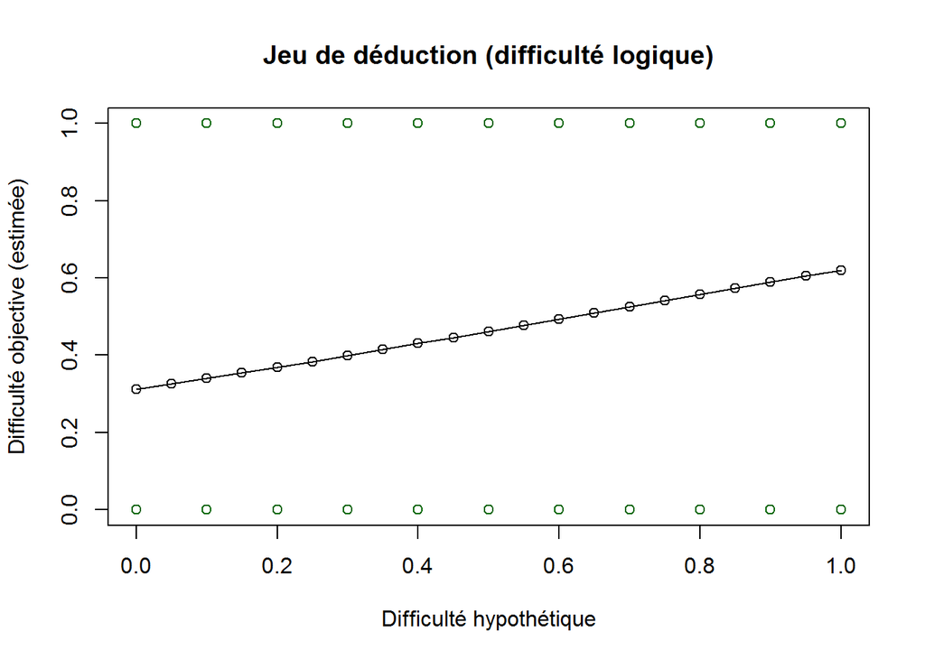

```
## [1] "Fails: 0.25"
## [1] "Wins: 0.25"
## [1] "Lissee: 0.25"
```

```
##
## Call:
## glm(formula = evalDiffBin ~ difficulty, family = binomial(link = "logit"),
##     data = DTLoc)
##
## Deviance Residuals:
##     Min       1Q   Median       3Q      Max
## -1.9519  -0.8773  -0.7078   1.0758   1.9574
##
## Coefficients:
##             Estimate Std. Error z value Pr(>|z|)
## (Intercept) -1.75638    0.09458  -18.57   <2e-16 ***
## difficulty   5.00034    0.32621   15.33   <2e-16 ***
## ---
## Signif. codes:  0 '***' 0.001 '**' 0.01 '*' 0.05 '.' 0.1 ' ' 1
##
## (Dispersion parameter for binomial family taken to be 1)
##
##     Null deviance: 3043.6  on 2309  degrees of freedom
## Residual deviance: 2770.7  on 2308  degrees of freedom
## AIC: 2774.7
##
## Number of Fisher Scoring iterations: 4
```

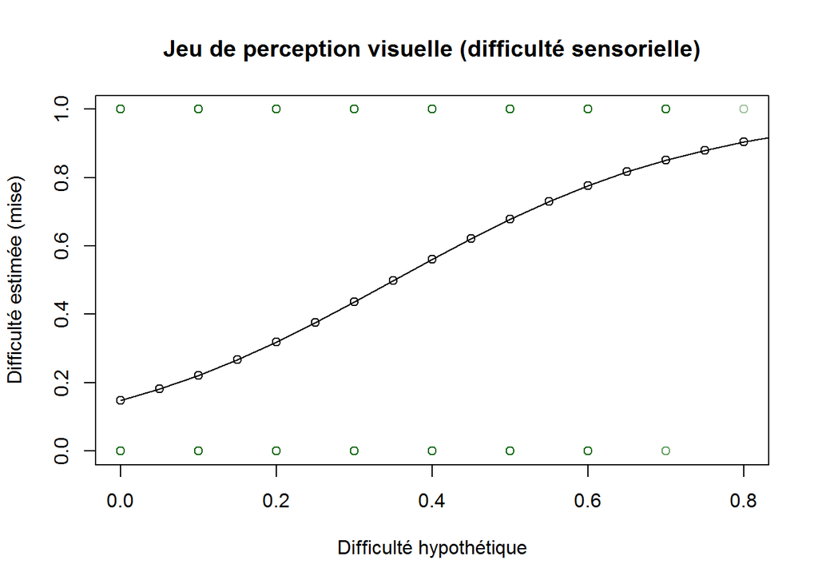

```
##
## Call:
## glm(formula = perdant ~ difficulty, family = binomial(link = "logit"),
##     data = DTLoc)
##
## Deviance Residuals:
##     Min       1Q   Median       3Q      Max
## -2.1762  -1.0494  -0.6819   1.0910   1.7736
##
## Coefficients:
##             Estimate Std. Error z value Pr(>|z|)
## (Intercept) -1.34023    0.08803  -15.22   <2e-16 ***
## difficulty   5.15678    0.32448   15.89   <2e-16 ***
## ---
## Signif. codes:  0 '***' 0.001 '**' 0.01 '*' 0.05 '.' 0.1 ' ' 1
##
## (Dispersion parameter for binomial family taken to be 1)
##
##     Null deviance: 3192.1  on 2309  degrees of freedom
## Residual deviance: 2893.8  on 2308  degrees of freedom
## AIC: 2897.8
##
## Number of Fisher Scoring iterations: 4
```

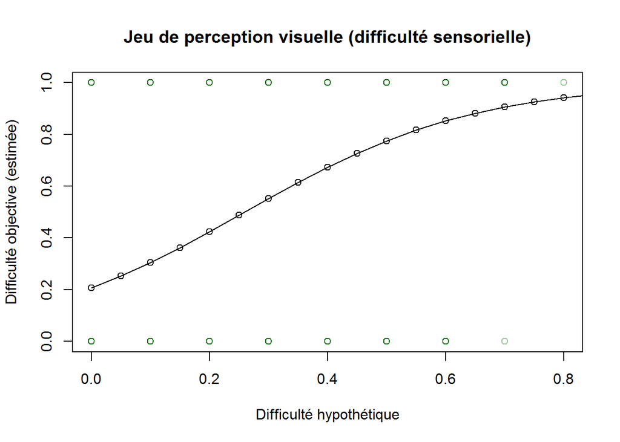

```
## [1] "Fails: 0.25"
## [1] "Wins: 0.23"
## [1] "Lissee: 0.25"
```

```
##
## Call:
## glm(formula = evalDiffBin ~ difficulty, family = binomial(link = "logit"),
##     data = DTLoc)
##
## Deviance Residuals:
##     Min       1Q   Median       3Q      Max
## -0.9857  -0.9535  -0.9429   1.4130   1.4440
##
## Coefficients:
##             Estimate Std. Error z value Pr(>|z|)
## (Intercept) -0.60792    0.07682  -7.913 2.51e-15 ***
## difficulty   0.13865    0.17499   0.792    0.428
## ---
## Signif. codes:  0 '***' 0.001 '**' 0.01 '*' 0.05 '.' 0.1 ' ' 1
##
## (Dispersion parameter for binomial family taken to be 1)
##
##     Null deviance: 3108.3  on 2369  degrees of freedom
## Residual deviance: 3107.7  on 2368  degrees of freedom
## AIC: 3111.7
##
## Number of Fisher Scoring iterations: 4
```

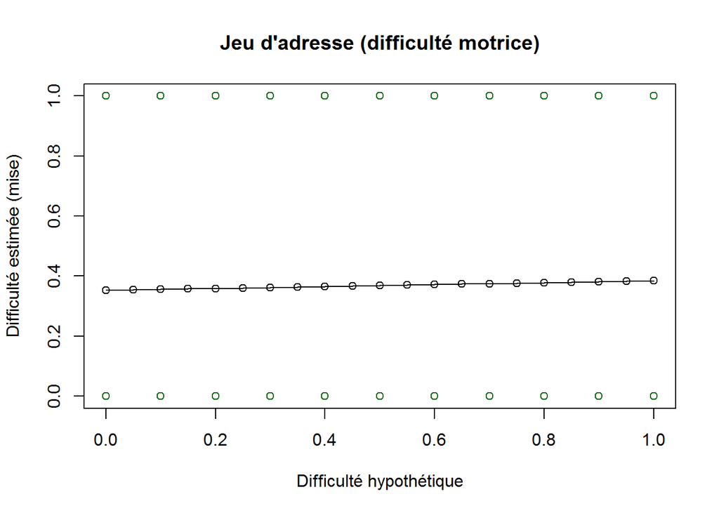

```
##
## Call:
## glm(formula = perdant ~ difficulty, family = binomial(link = "logit"),
##     data = DTLoc)
##
## Deviance Residuals:
##     Min       1Q   Median       3Q      Max
## -1.3522  -1.0896  -0.9845   1.2299   1.3834
##
## Coefficients:
##             Estimate Std. Error z value Pr(>|z|)
## (Intercept) -0.47228    0.07498  -6.298 3.01e-10 ***
## difficulty   0.87430    0.17125   5.105 3.30e-07 ***
## ---
## Signif. codes:  0 '***' 0.001 '**' 0.01 '*' 0.05 '.' 0.1 ' ' 1
##
## (Dispersion parameter for binomial family taken to be 1)
##
##     Null deviance: 3271.5  on 2369  degrees of freedom
## Residual deviance: 3245.1  on 2368  degrees of freedom
## AIC: 3249.1
##
## Number of Fisher Scoring iterations: 4
```

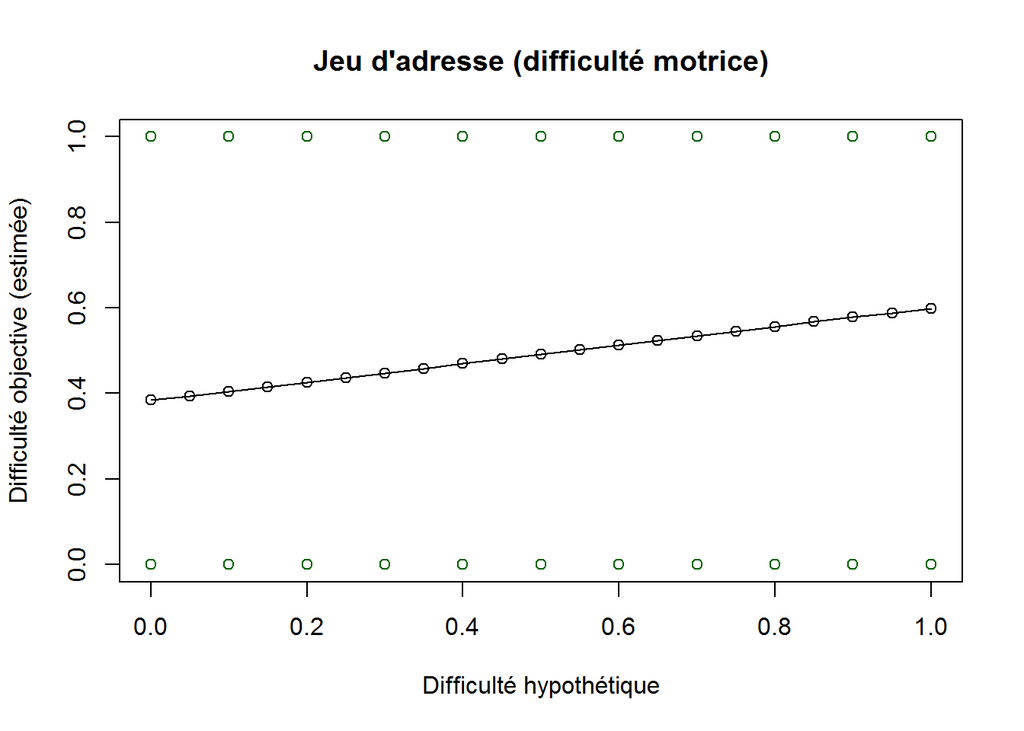

```
## [1] "Fails: 0.25"
## [1] "Wins: 0.25"
## [1] "Lissee: 0.27"
```

# Description datas

Au total, **79** joueurs dans le dataset avant suppression des outliers, donc 2370 lignes dans la table.

## Ecart type de la mise

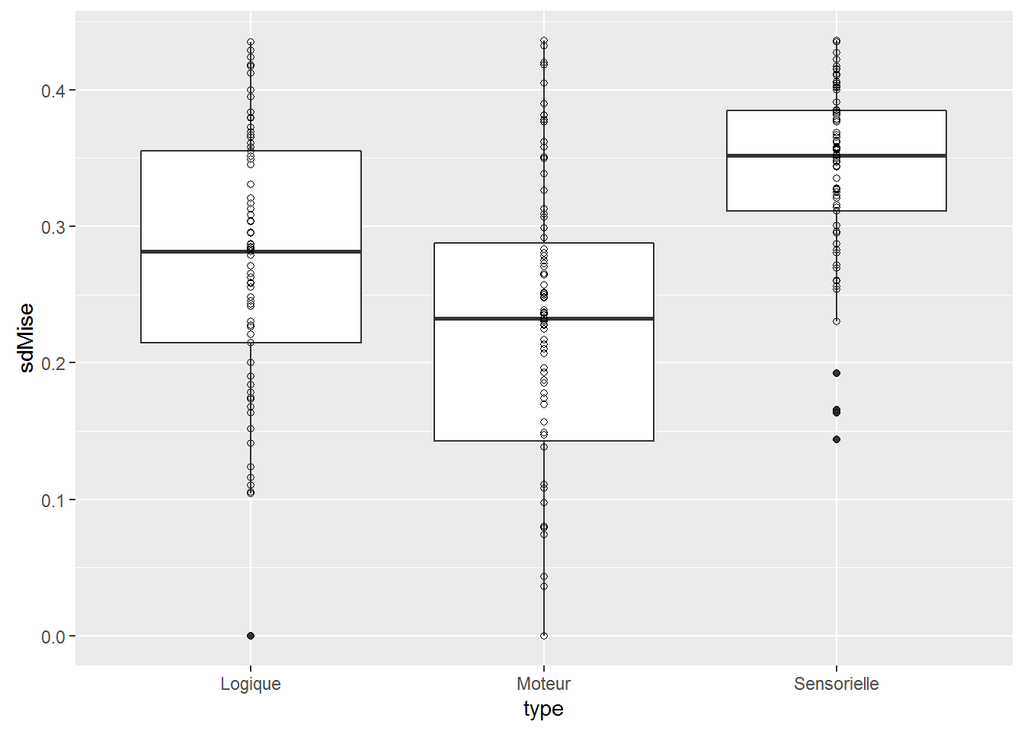

```
## [1] "Id out motrice sdMise: "
```

```
## [1] "Id out senso sdMise: lpc2zjkex, 9l7s14ocz, srn0c21wi, g6m2iu73e"
```

```
## [1] "Id out logique sdMise: 9l7s14ocz, 135499aaw"
```

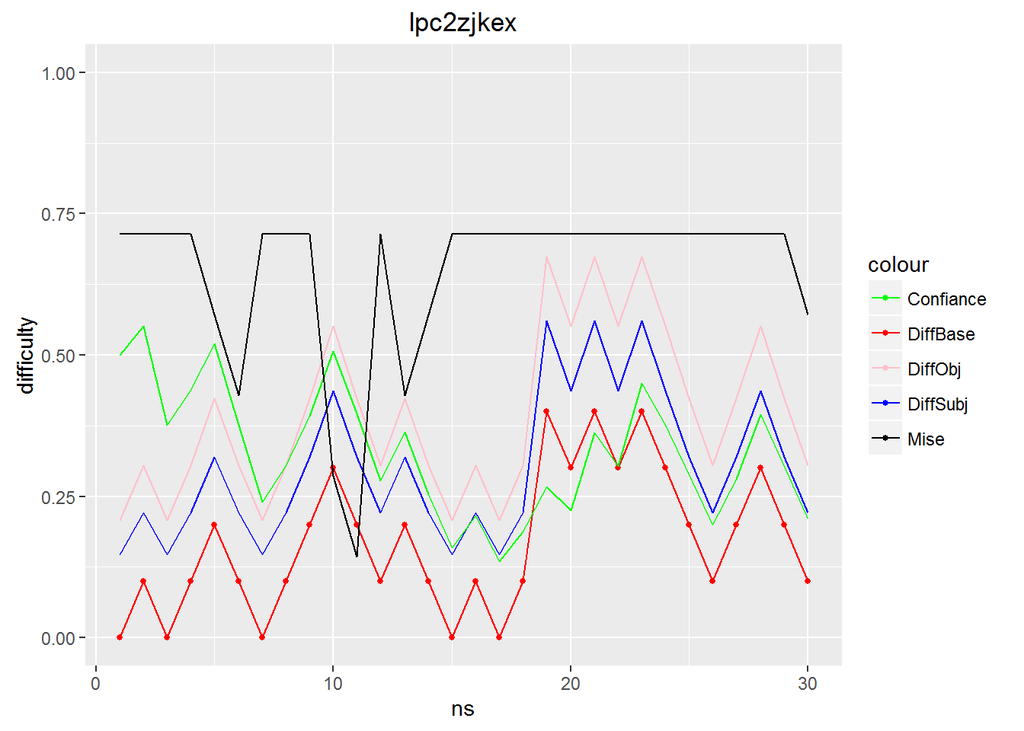

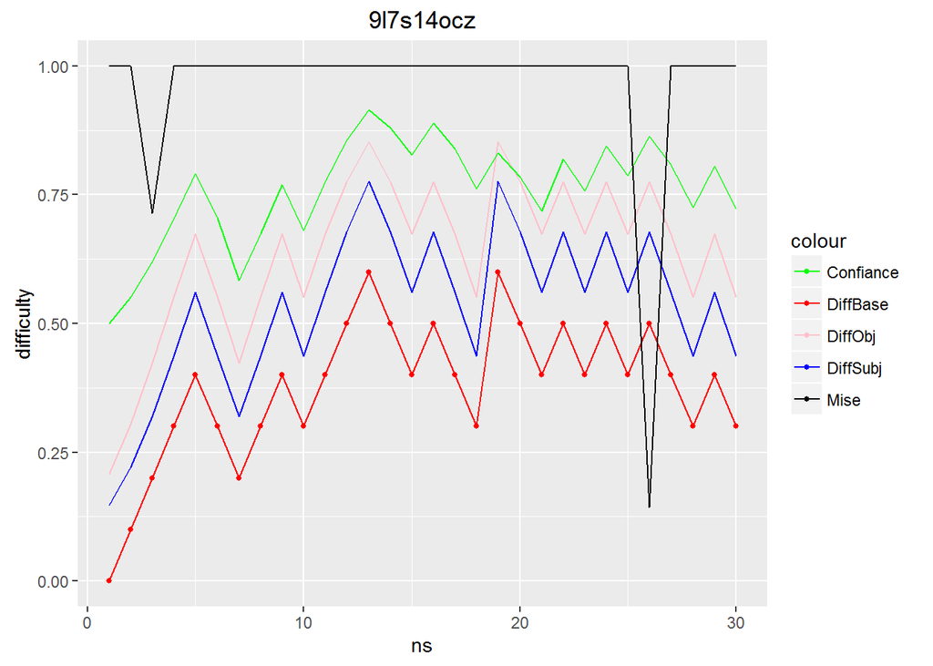

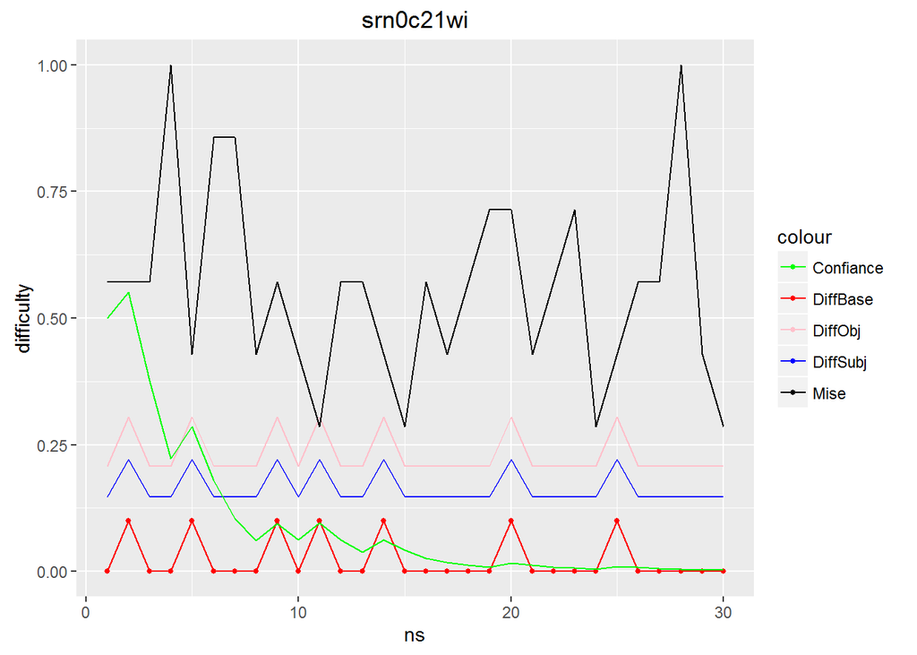

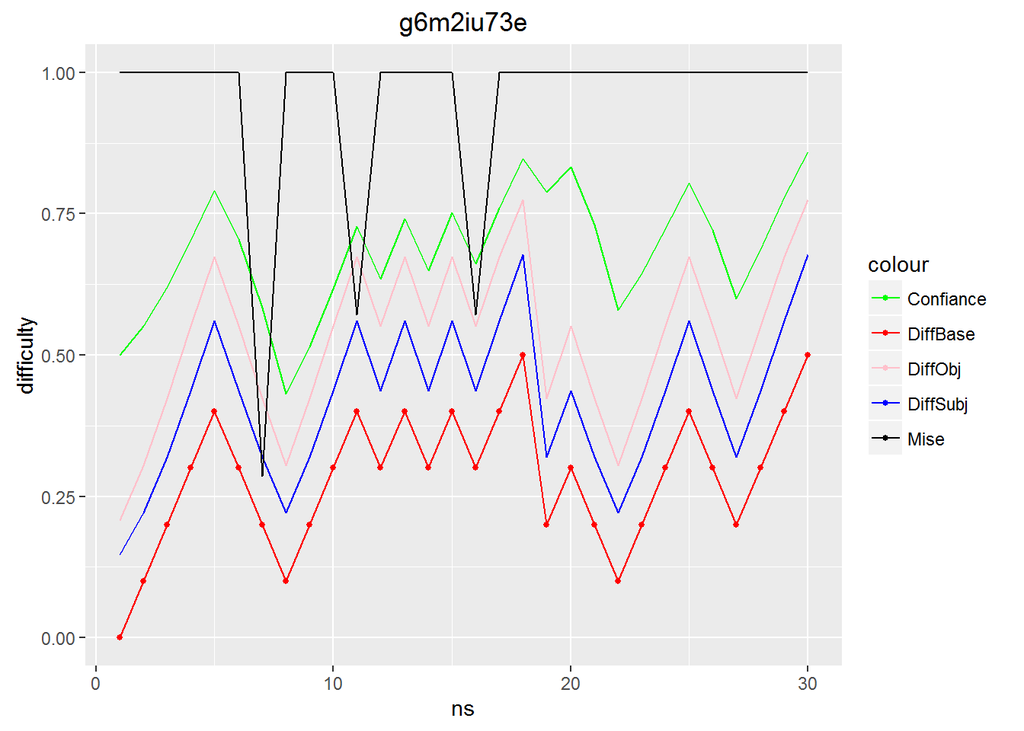

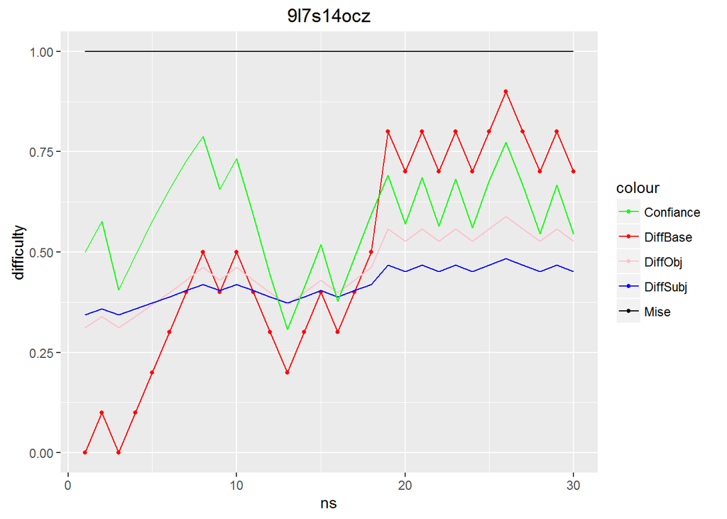

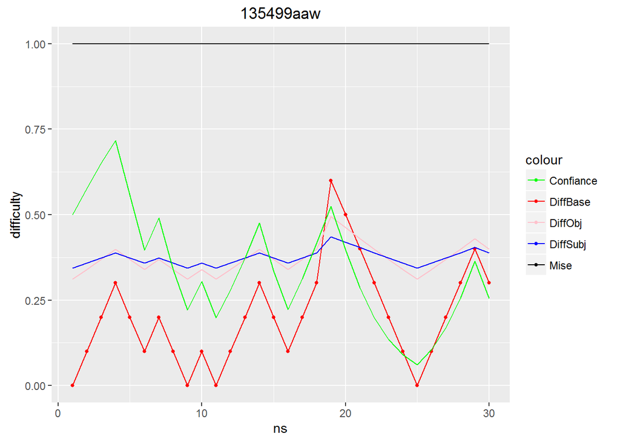

## Moyenne de la mise

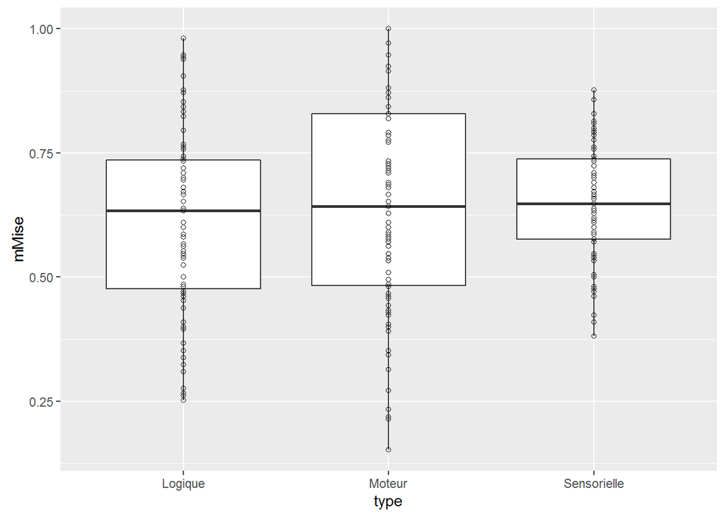

```
## [1] "Id out motrice mMise: "
```

```
## [1] "Id out senso mMise: "
```

```
## [1] "Id out logique mMise: "
```

## Somme des mises

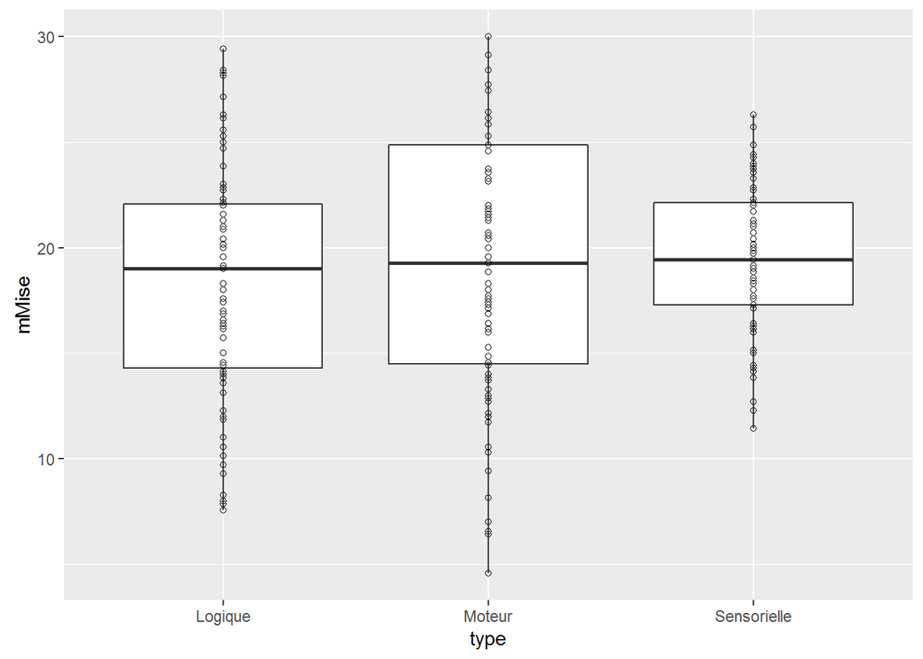

```
## [1] "Id out motrice sum Mise: "
```

```
## [1] "Id out senso sum Mise: "
```

```
## [1] "Id out logique sum Mise: "
```

## Difficulte constatée $\sum(win)$

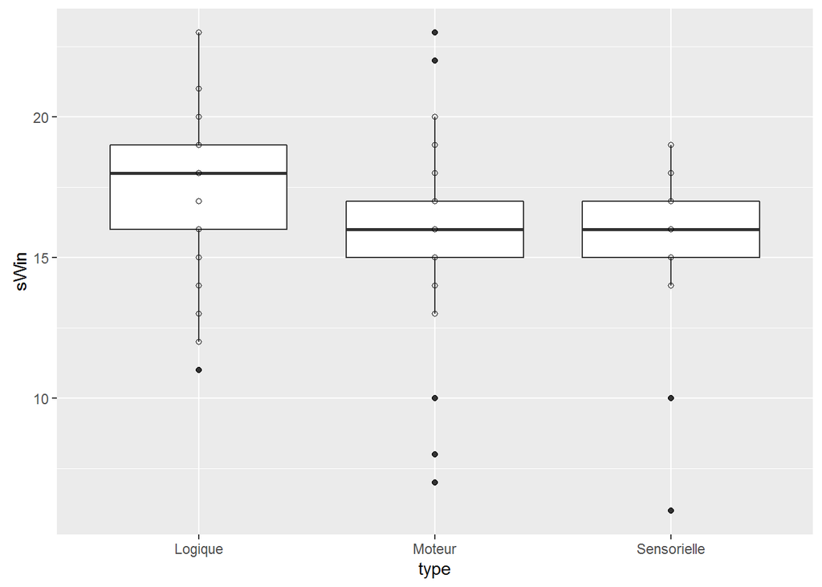

```
## [1] "Id out motrice sum win: l6ehn7zmg, sazum1pbv, gtctvcic1, hyp4gi7jq, 2zib9h0du, at13n1mb2, mk1cf0rb0"
```

```
## [1] "Id out senso sum win: sazum1pbv, at13n1mb2"
```

```
## [1] "Id out logique sum win: ybc3acutd"
```

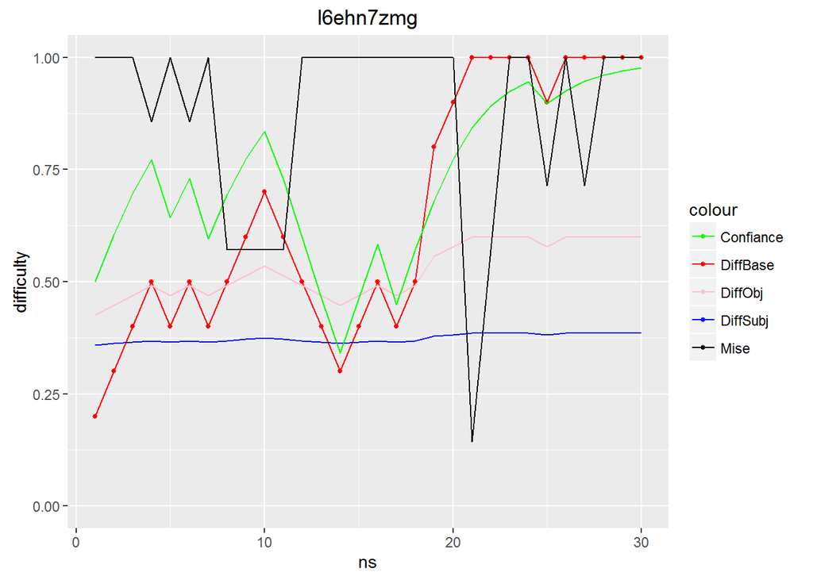

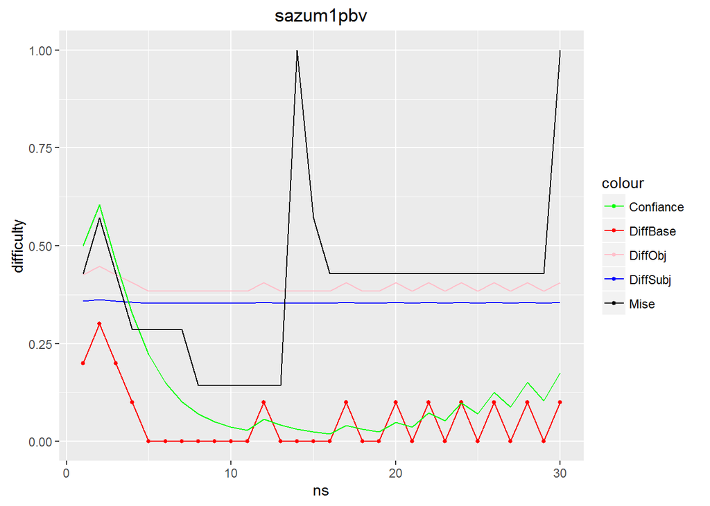

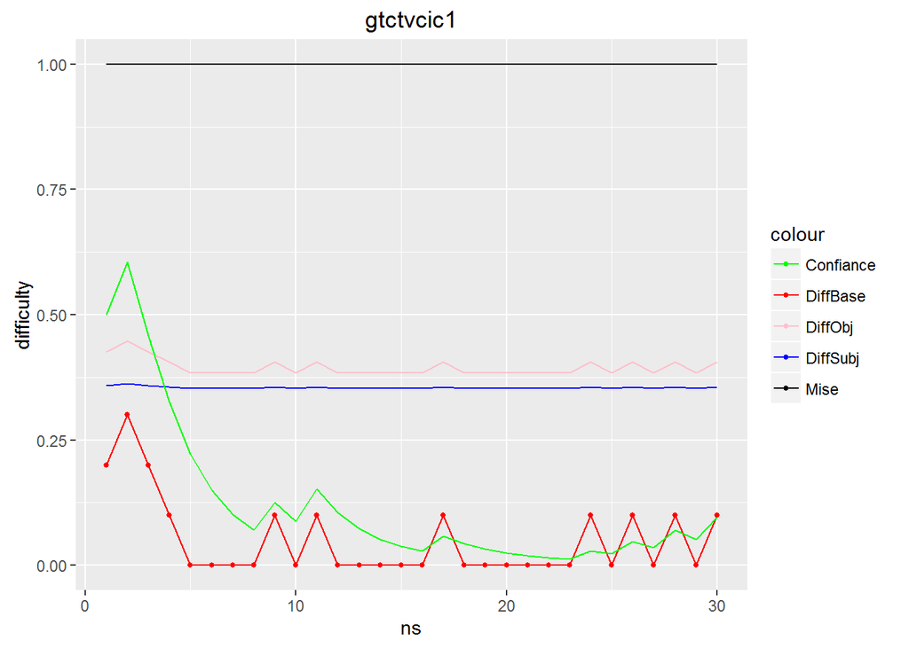

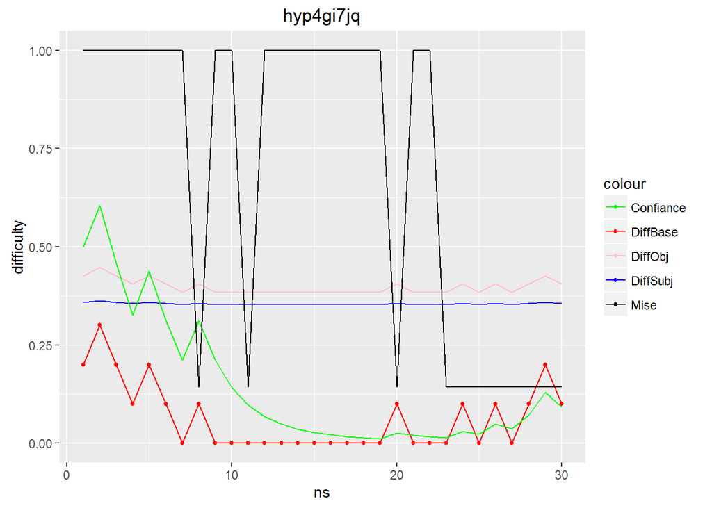

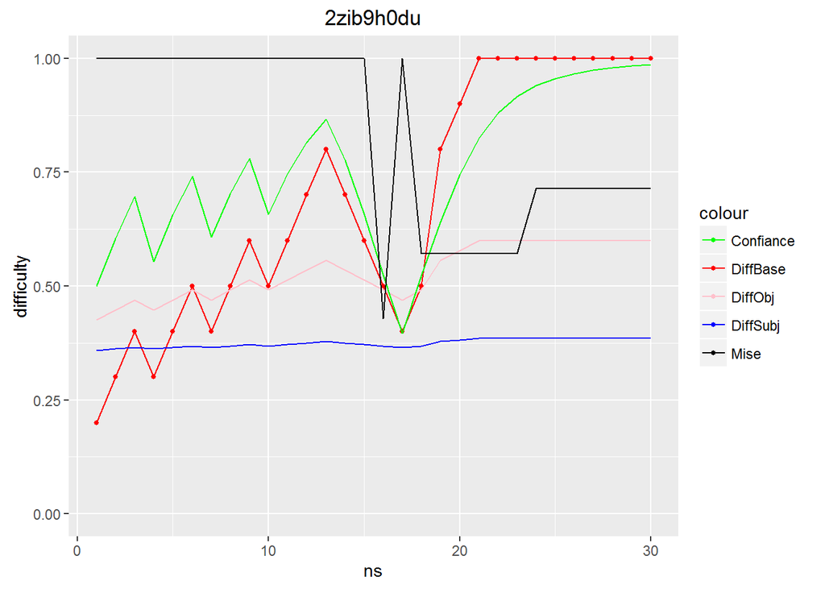

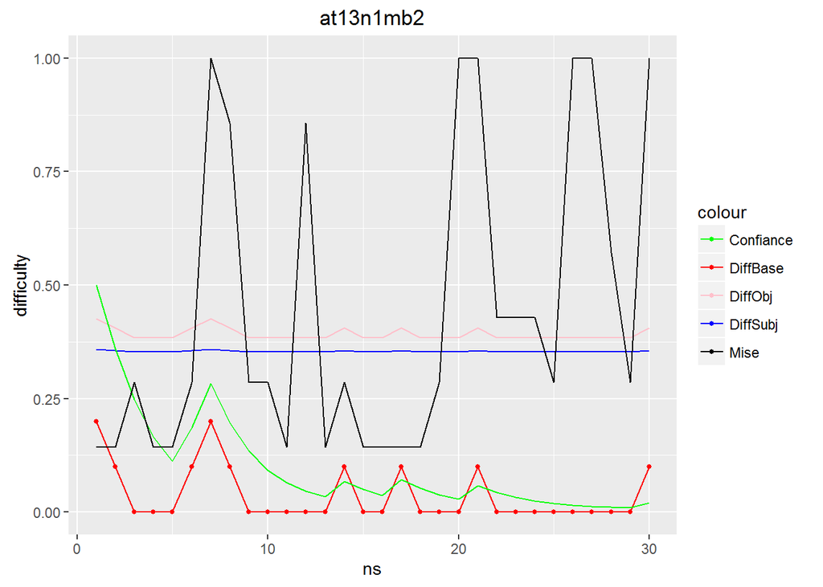

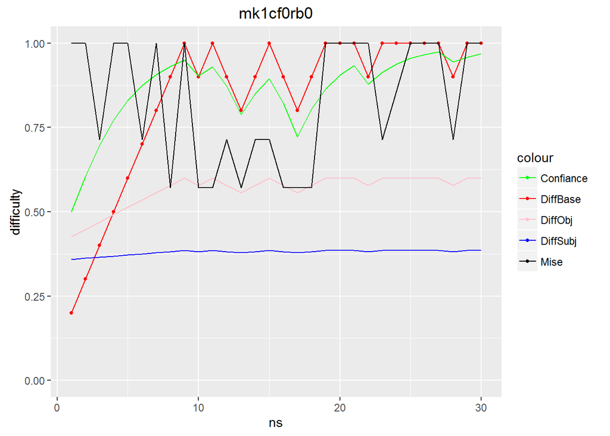

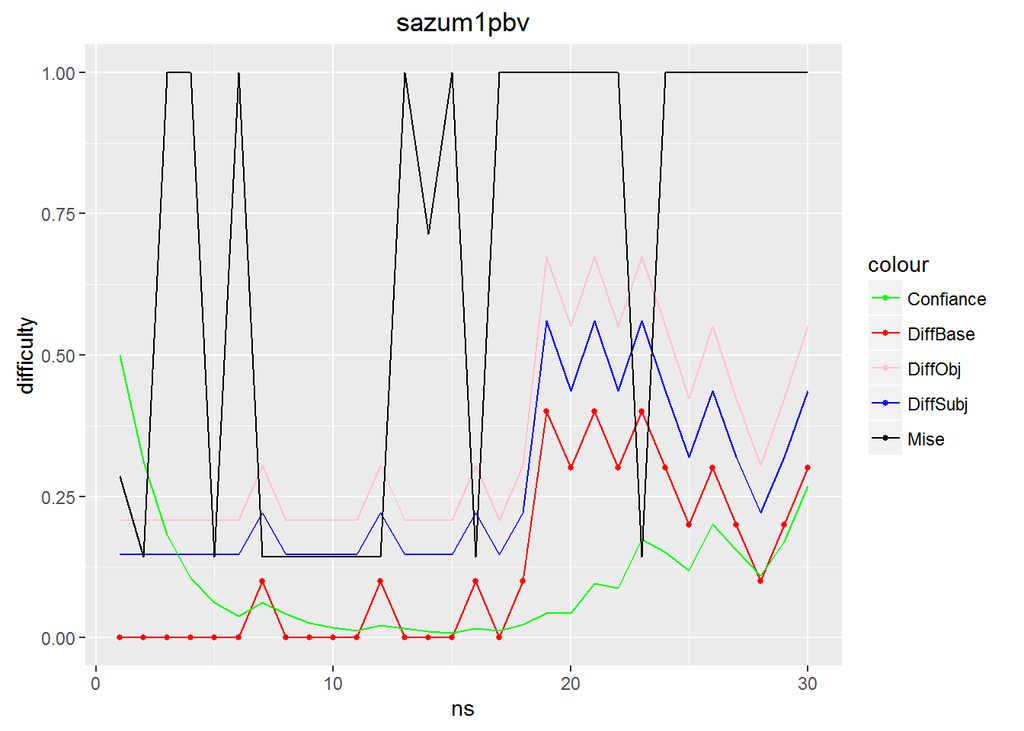

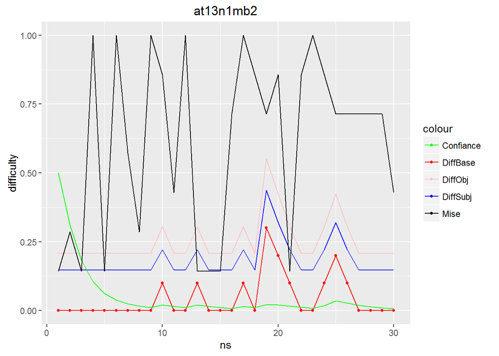

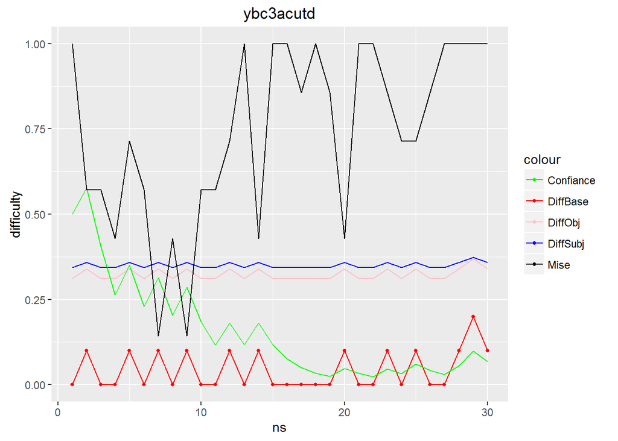

## Comportement stratégique (moutons sauves)

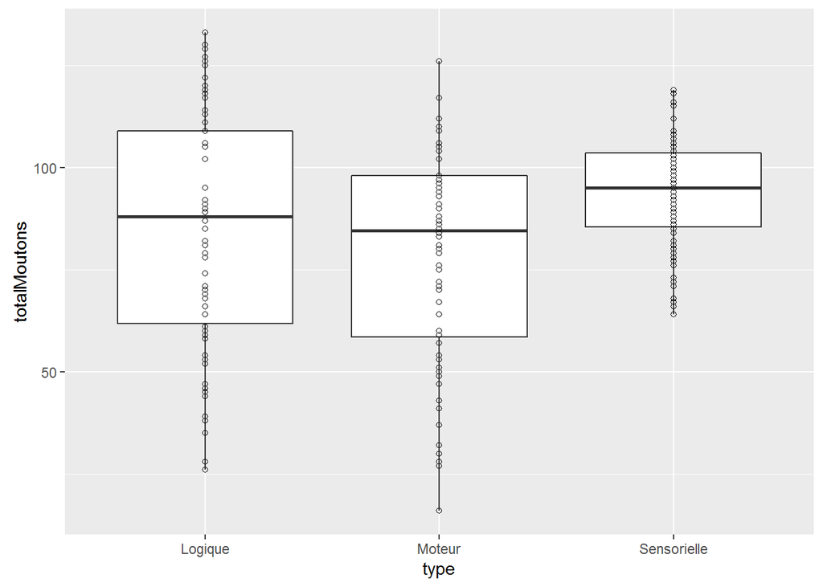

```
## [1] "Id out motrice moutons: "
```

```
## [1] "Id out senso moutons: "
```

```
## [1] "Id out logique moutons: "
```

## Comportement stratégique (moutons perdus)

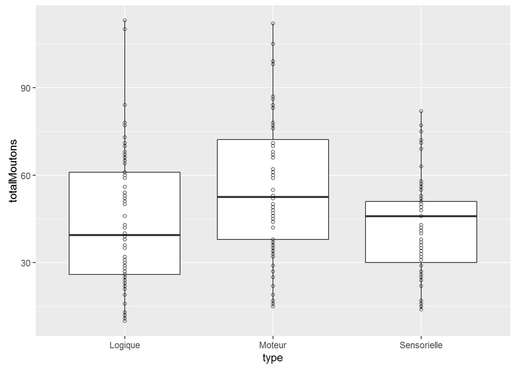

```
## [1] "Id out motrice moutons: "
```

```
## [1] "Id out senso moutons: "
```

```
## [1] "Id out logique moutons: "
```

## Comportement stratégique (alternance win fail)

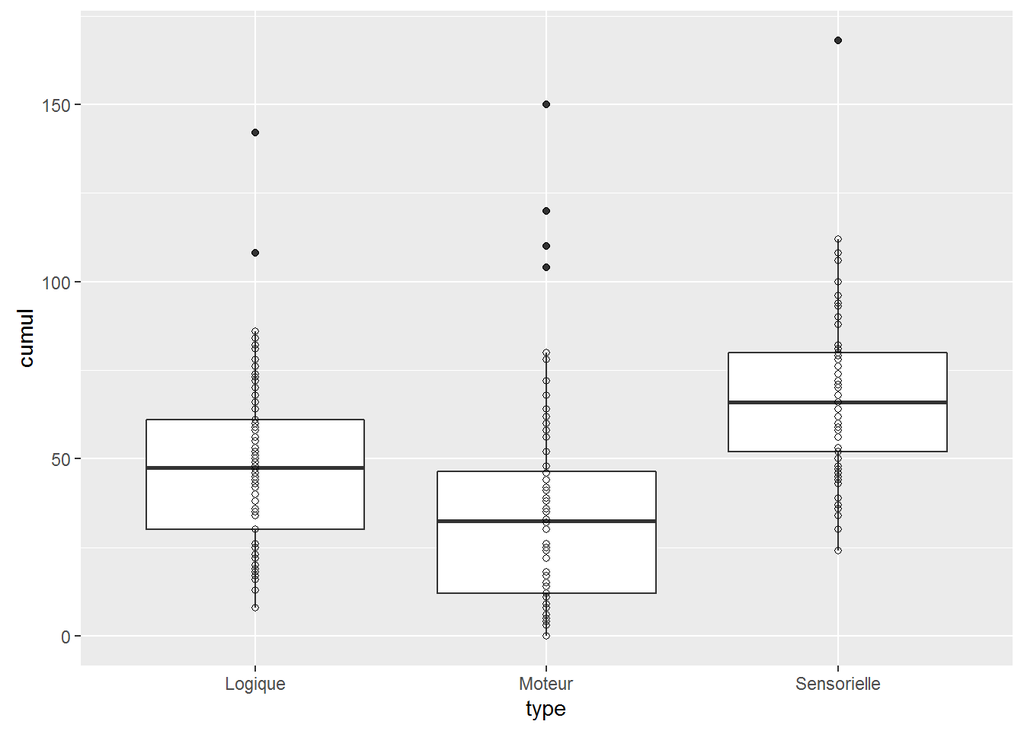

```
## [1] "Id out motrice moutons: e0tdz7cvh, 3t1l09dyk, 2lvqyyzt9, byo2x6jan"
```

```
## [1] "Id out senso moutons: e0tdz7cvh"
```

```
## [1] "Id out logique moutons: 3t1l09dyk, b62w478su"
```

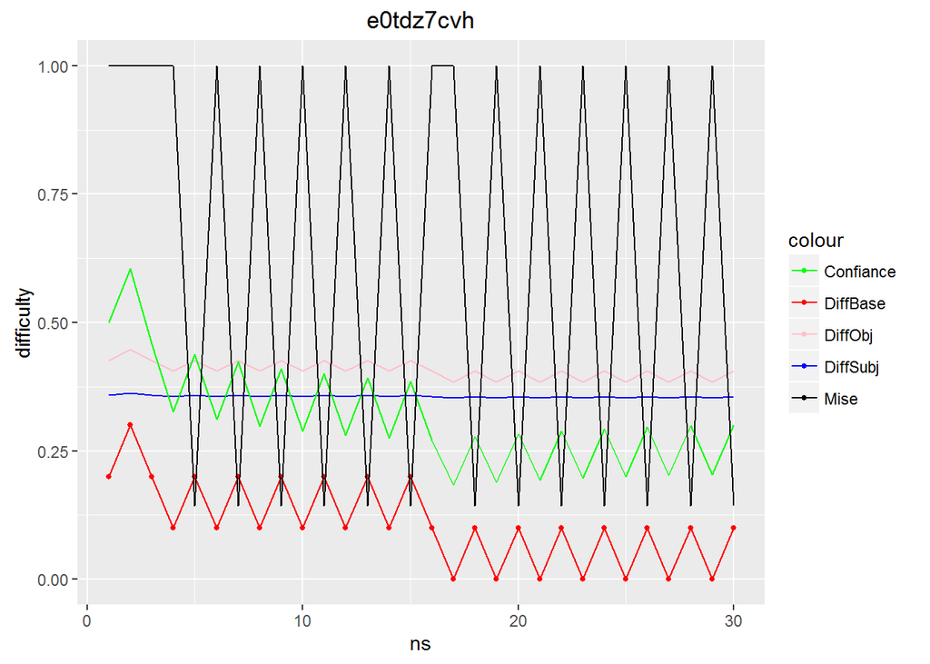

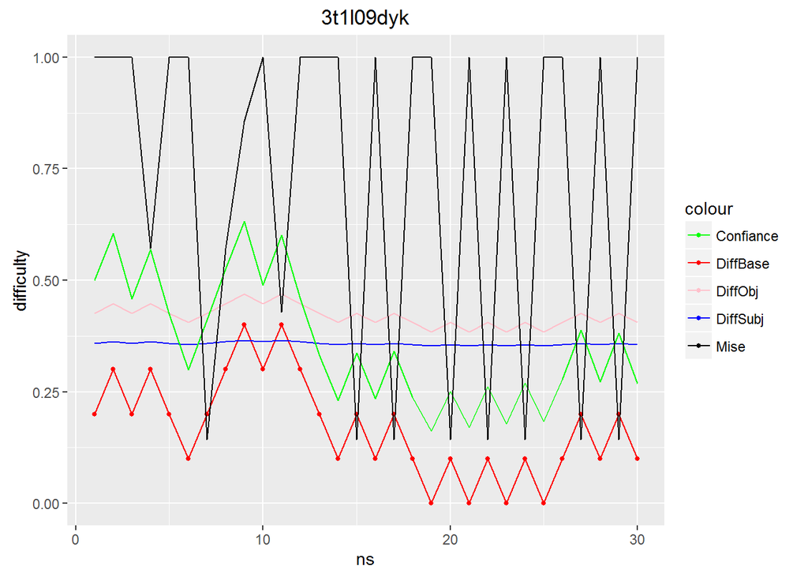

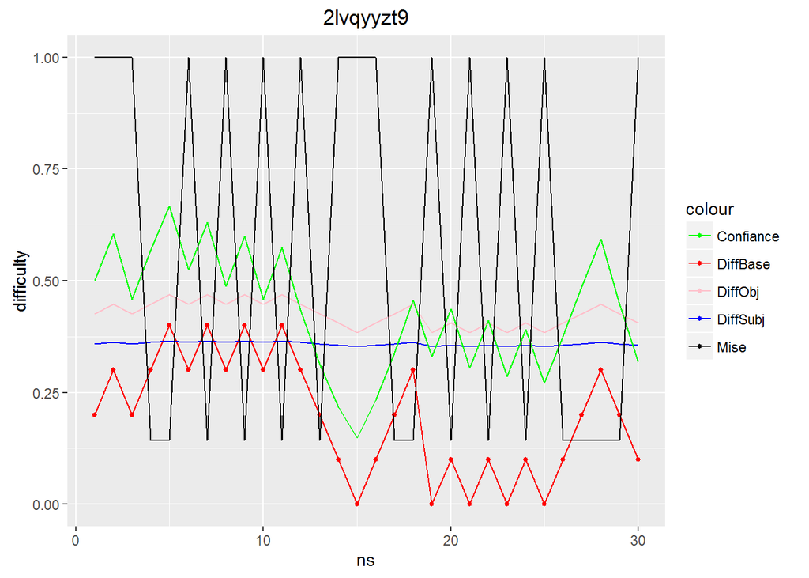